# STAT 540 Seminar 05: Fitting and interpreting linear models (low volume)

## STAT 540 Seminar 05: Fitting and interpreting linear models (low volume)

### Hao Chen

**2014-02-28**

- Repeat the examples in the seminar
- Take-home exercise

> The R markdown file can be found on my [Github](https://github.com/nelsonch/stat540-2014-chen-hao/blob/master/seminar%2005/seminar05.Rmd).

The following data files will be used in this seminar:

- GSE4051_data.tsv: full data matrix
- GSE4051_design.rds: experimental design

Load these data files:

```r
> prDat <- read.table("GSE4051_data.tsv")
> str(prDat, list.len = 5)
```

```
'data.frame':   29949 obs. of  39 variables:
 $ Sample_20: num  7.24 9.48 10.01 8.36 8.59 ...
 $ Sample_21: num  7.41 10.02 10.04 8.37 8.62 ...
 $ Sample_22: num  7.17 9.85 9.91 8.4 8.52 ...
 $ Sample_23: num  7.07 10.13 9.91 8.49 8.64 ...
 $ Sample_16: num  7.38 7.64 8.42 8.36 8.51 ...
  [list output truncated]
```

```r
> prDes <- readRDS("GSE4051_design.rds")
> str(prDes)
```

```
'data.frame':   39 obs. of  4 variables:
 $ sidChar : chr  "Sample_20" "Sample_21" "Sample_22" "Sample_23" ...
 $ sidNum  : num  20 21 22 23 16 17 6 24 25 26 ...
 $ devStage: Factor w/ 5 levels "E16","P2","P6",..: 1 1 1 1 1 1 1 2 2 2 ...
 $ gType   : Factor w/ 2 levels "wt","NrlKO": 1 1 1 1 2 2 2 1 1 1 ...
```

Load required R packages:

```r
> library(lattice)
```

### Repeat the examples in the seminar

#### Write a function to prepare and stripplot a mini-dataset for a small number of genes.

```r
> prepareData <- function(myGenes) {
+     miniDat <- t(prDat[myGenes, ])
+     miniDat <- data.frame(gExp = as.vector(miniDat),
+                           gene = factor(rep(colnames(miniDat), each =
+                           nrow(miniDat)), levels = colnames(miniDat)))
+     miniDat <- suppressWarnings(data.frame(prDes, miniDat))
+     miniDat
+ }
>
> stripplotIt <- function(myData,...) {
+     stripplot(gExp ~ devStage | gene, myData, group = gType, jitter.data = TRUE,
+               auto.key = TRUE, type = c('p', 'a'), grid = TRUE, ...)
+ }
```

Test if the functions work properly.

```r
> luckyGenes <- c("1419655_at","1438815_at")
> jDat <- prepareData(luckyGenes)
> str(jDat)
```

```
'data.frame':   78 obs. of  6 variables:
 $ sidChar : chr  "Sample_20" "Sample_21" "Sample_22" "Sample_23" ...
 $ sidNum  : num  20 21 22 23 16 17 6 24 25 26 ...
 $ devStage: Factor w/ 5 levels "E16","P2","P6",..: 1 1 1 1 1 1 1 2 2 2 ...
 $ gType   : Factor w/ 2 levels "wt","NrlKO": 1 1 1 1 2 2 2 1 1 1 ...
 $ gExp    : num  10.93 10.74 10.67 10.68 9.61 ...
 $ gene    : Factor w/ 2 levels "1419655_at","1438815_at": 1 1 1 1 1 1 1 1 1 1 ...
```

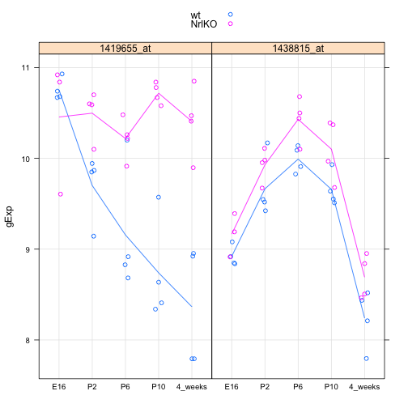

```r
> stripplotIt(jDat)
```

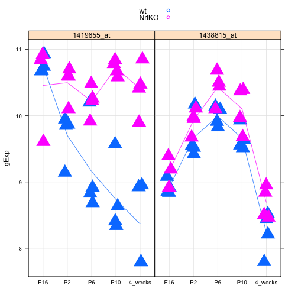

```r
> stripplotIt(jDat, pch = 17, cex = 3)
```

#### Do a two-sample t-test

Let's test for a difference in expected gene expression for probeset “1456341_a_at” at developmental stage P2 vs. 4 weeks post-natal (ignoring genotype, i.e. lump the wild types and knockouts together). Let's assume a common variance in the two groups.

```r
> newDat <- prepareData("1456341_a_at")
> t.test(gExp ~ devStage, newDat, var.equal = TRUE,
+        subset = devStage %in% c("P2", "4_weeks"))
```

```
    Two Sample t-test

data:  gExp by devStage
t = -18.84, df = 14, p-value = 2.411e-11
alternative hypothesis: true difference in means is not equal to 0
95 percent confidence interval:
 -4.078 -3.244
sample estimates:
     mean in group P2 mean in group 4_weeks
                6.326                 9.987
```

#### Fit a linear model with a categorical covariate

Focus on probeset “1438786_a_at”.

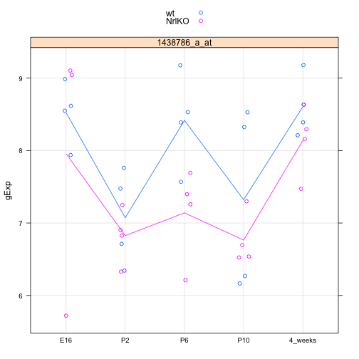

```r
> stripplotIt(mDat <- prepareData("1438786_a_at"))
```

Focus just on the wild type data for now. Model expression as a function of the devStage factor.

```r
> mFit <- lm(gExp ~ devStage, mDat, subset = gType == "wt")
> summary(mFit)
```

```
Call:
lm(formula = gExp ~ devStage, data = mDat, subset = gType ==
    "wt")

Residuals:
    Min      1Q  Median      3Q     Max
-1.1565 -0.4400  0.0288  0.4915  1.2065

Coefficients:
                Estimate Std. Error t value Pr(>|t|)
(Intercept)        8.523      0.379   22.50  5.7e-13 ***
devStageP2        -1.450      0.536   -2.71    0.016 *
devStageP6        -0.107      0.536   -0.20    0.845
devStageP10       -1.201      0.536   -2.24    0.040 *
devStage4_weeks    0.081      0.536    0.15    0.882
---
Signif. codes:  0 '***' 0.001 '**' 0.01 '*' 0.05 '.' 0.1 ' ' 1

Residual standard error: 0.758 on 15 degrees of freedom
Multiple R-squared:  0.497, Adjusted R-squared:  0.363
F-statistic: 3.71 on 4 and 15 DF,  p-value: 0.0272
```

#### Perform inference for a contrast

test whether the P2 and P10 effects are equal or, equivalently, whether their difference is equal to zero.

```r
> coef(mFit)
```

```
    (Intercept)      devStageP2      devStageP6     devStageP10
         8.5227         -1.4503         -0.1067         -1.2012
devStage4_weeks
         0.0810
```

```r
> contMat <- matrix(c(0, 1, 0, -1, 0), nrow = 1)
> (obsDiff <- contMat %*% coef(mFit))
```

```
       [,1]
[1,] -0.249
```

Check that this really is the observed difference in sample mean for the wild type mice, P2 vs. P10.

```r
> (sampMeans <- aggregate(gExp ~ devStage, mDat, FUN = mean,
+                         subset = gType == "wt"))
```

```
  devStage  gExp
1      E16 8.523
2       P2 7.072
3       P6 8.416
4      P10 7.322
5  4_weeks 8.604
```

```r
> with(sampMeans, gExp[devStage == "P2"] - gExp[devStage == "P10"])
```

```
[1] -0.249
```

- Agrees with the observed difference we computed by multiplying our contrast matrix and the estimated parameters.

The variance-covariance matrix of the parameters estimated in the original model can be obtained with `vcov()` and is equal to \((X^{T}X)^{-1}\hat{\sigma}^{2}\).

```r
> all(summary(mFit)$coefficients[ , "Std. Error"] == sqrt(diag(vcov(mFit))))
```

```
[1] TRUE
```

Returning to our test of the P2 vs. P10 contrast, recall that the variance-covariance matrix of a contrast obtained as \(C\hat{\alpha}\) is \(C(X^{T}X)^{-1}C^{T}\hat{\sigma}^{2}\).

```r
> (estSe <- contMat %*% vcov(mFit) %*% t(contMat))
```

```
      [,1]
[1,] 0.287
```

```r
> (testStat <- obsDiff/estSe)
```

```
        [,1]
[1,] -0.8676
```

```r
> 2 * pt(abs(testStat), df = df.residual(mFit), lower.tail = FALSE)
```

```
       [,1]
[1,] 0.3993
```

- This p-value is rather large and we conclude there is no difference.

#### Fit a linear model with two categorical covariates

Let's focus on probeset “1448690_at”.

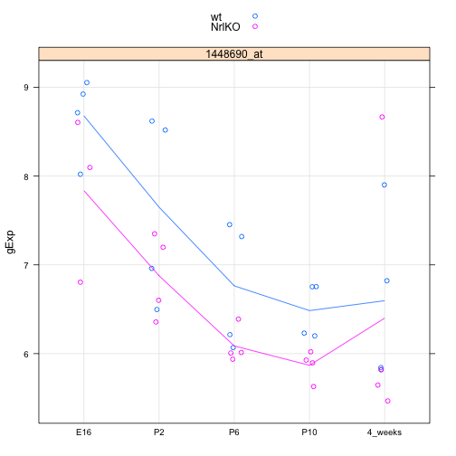

```r
> stripplotIt(oDat <- prepareData("1448690_at"))
```

```r
> oFitBig <- lm(gExp ~ gType * devStage, oDat)
> summary(oFitBig)$coef
```

```
                           Estimate Std. Error  t value  Pr(>|t|)
(Intercept)                 8.67800     0.3987 21.76755 1.634e-19
gTypeNrlKO                 -0.84233     0.6090 -1.38320 1.772e-01
devStageP2                 -1.02900     0.5638 -1.82512 7.830e-02
devStageP6                 -1.91450     0.5638 -3.39571 2.003e-03
devStageP10                -2.19325     0.5638 -3.89012 5.387e-04
devStage4_weeks            -2.08200     0.5638 -3.69280 9.149e-04
gTypeNrlKO:devStageP2       0.06983     0.8299  0.08415 9.335e-01
gTypeNrlKO:devStageP6       0.16533     0.8299  0.19922 8.435e-01
gTypeNrlKO:devStageP10      0.22583     0.8299  0.27212 7.875e-01
gTypeNrlKO:devStage4_weeks  0.64608     0.8299  0.77852 4.426e-01
```

Fit a related, smaller model with the same covariates, but this time omit the interaction.

```r
> oFitSmall <- lm(gExp ~ gType + devStage, oDat)
> anova(oFitSmall, oFitBig)
```

```
Analysis of Variance Table

Model 1: gExp ~ gType + devStage
Model 2: gExp ~ gType * devStage
  Res.Df  RSS Df Sum of Sq   F Pr(>F)
1     33 18.9
2     29 18.4  4     0.497 0.2   0.94
```

- With a p-value awfully close to one, we confirm that, no, there is no evidence for interaction in this particular case.

To get a more exciting result, take a look at probeset “1429225_at”.

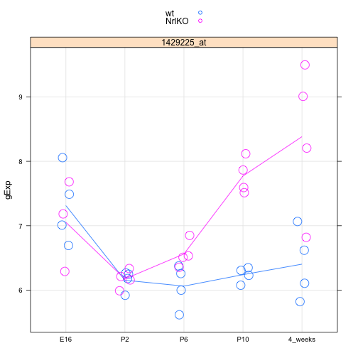

```r
> stripplotIt(pDat <- prepareData("1429225_at"), cex = 2)
```

```r
> pFitBig <- lm(gExp ~ gType * devStage, pDat)
> pFitSmall <- lm(gExp ~ gType + devStage, pDat)
> anova(pFitSmall, pFitBig)
```

```
Analysis of Variance Table

Model 1: gExp ~ gType + devStage
Model 2: gExp ~ gType * devStage
  Res.Df   RSS Df Sum of Sq    F Pr(>F)
1     33 15.12
2     29  7.95  4      7.17 6.54  7e-04 ***
---
Signif. codes:  0 '***' 0.001 '**' 0.01 '*' 0.05 '.' 0.1 ' ' 1
```

- The interaction here is highly statistically significant.

### Take-home exercise

#### 1. Can you use data aggregation strategies from last week to do model fitting for small sets of genes?

Load `plyr` package.

```r
> library(plyr)
```

```r
> modelFit <- function(jDat){
+   foo <- dlply(jDat, ~ gene, function(x){
+     Fit <- lm(gExp ~ gType * devStage, data = x)
+   })
+   return(foo)
+ }
```

Use probes “1419655_at” and “1438815_at” to test if the function works.

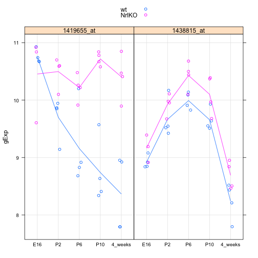

```r
> jDat <- prepareData(c("1419655_at","1438815_at"))
> stripplotIt(jDat)
```

```r
> modelFit(jDat)
```

```
$`1419655_at`

Call:
lm(formula = gExp ~ gType * devStage, data = x)

Coefficients:
               (Intercept)                  gTypeNrlKO
                     10.75                       -0.30
                devStageP2                  devStageP6
                     -1.05                       -1.60
               devStageP10             devStage4_weeks
                     -2.02                       -2.39
     gTypeNrlKO:devStageP2       gTypeNrlKO:devStageP6
                      1.10                        1.36
    gTypeNrlKO:devStageP10  gTypeNrlKO:devStage4_weeks
                      2.28                        2.34


$`1438815_at`

Call:
lm(formula = gExp ~ gType * devStage, data = x)

Coefficients:
               (Intercept)                  gTypeNrlKO
                    8.9213                      0.2447
                devStageP2                  devStageP6
                    0.7435                      1.0705
               devStageP10             devStage4_weeks
                    0.7370                     -0.6808
     gTypeNrlKO:devStageP2       gTypeNrlKO:devStageP6
                    0.0195                      0.1935
    gTypeNrlKO:devStageP10  gTypeNrlKO:devStage4_weeks
                    0.1988                      0.2058


attr(,"split_type")
[1] "data.frame"
attr(,"split_labels")
        gene
1 1419655_at
2 1438815_at
```

#### 2. Experiment with a quantitative version of devStage, which we called `age`. Can you fit linear and quadratic models to the expression data for one or several genes? How you also can add fitted regression curves to your scatterplots?

Load `car` package.

```r
> library(car)
```

(a) Fit linear models

```r
> prDes$age <- recode(prDes$devStage,
+                     "'E16'=-2; 'P2'=2; 'P6'=6; 'P10'=10; '4_weeks'=28",
+                     as.factor.result = FALSE)
>
> modelFitLin <- function(jDat){
+   foo <- dlply(jDat, ~ gene, function(x){
+     Fit <- lm(gExp ~ gType * age, data = x)
+     })
+   return(foo)
+ }
>
> xyplotLin <- function(myData,...) {
+   xyplot(gExp ~ age | gene, myData, group = gType,
+          panel = panel.superpose,
+             panel.groups = function(x, y,...){
+               panel.xyplot(x, y,...)
+               panel.lmline(x, y,...)
+               })
+ }
```

Use probes “1419655_at” and “1438815_at” to test if the functions work.

```r
> gDat <- prepareData(c("1419655_at","1438815_at"))
> head(gDat)
```

```
    sidChar sidNum devStage gType age   gExp       gene
1 Sample_20     20      E16    wt  -2 10.930 1419655_at
2 Sample_21     21      E16    wt  -2 10.740 1419655_at
3 Sample_22     22      E16    wt  -2 10.670 1419655_at
4 Sample_23     23      E16    wt  -2 10.680 1419655_at
5 Sample_16     16      E16 NrlKO  -2  9.606 1419655_at
6 Sample_17     17      E16 NrlKO  -2 10.840 1419655_at
```

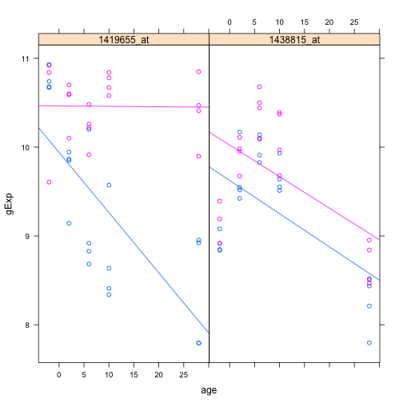

```r
> xyplotLin(gDat)
```

```r
> modelFitLin(gDat)
```

```
$`1419655_at`

Call:
lm(formula = gExp ~ gType * age, data = x)

Coefficients:
   (Intercept)      gTypeNrlKO             age  gTypeNrlKO:age
        9.9400          0.5240         -0.0678          0.0673


$`1438815_at`

Call:
lm(formula = gExp ~ gType * age, data = x)

Coefficients:
   (Intercept)      gTypeNrlKO             age  gTypeNrlKO:age
       9.62464         0.39823        -0.03742         0.00187


attr(,"split_type")
[1] "data.frame"
attr(,"split_labels")
        gene
1 1419655_at
2 1438815_at
```

(b) Fit quadratic models

```r
> modelFiteQua <- function(myData){
+   foo <- dlply(myData, ~ gene, function(x){
+     Fit <- lm(gExp ~ gType * (age + I(age^2)), data = x)
+     })
+   return(foo)
+ }
>
> xyplotQua <- function(myData,...) {
+   xyplot(gExp ~ age | gene, myData, group = gType,
+          panel = panel.superpose,
+          panel.groups = function(x, y,...){
+            fits <- lm(y ~ x + I(x^2))
+            panel.xyplot(x, y,...)
+            a0 <- summary(fits)$coefficient[1,"Estimate"]
+            a1 <- summary(fits)$coefficient[2,"Estimate"]
+            a2 <- summary(fits)$coefficient[3,"Estimate"]
+            yfit <- function(x){a0 + a1*x + a2*x^2}
+            panel.curve(yfit, from = -2, to = 28, n = 100,...)
+          })
+ }
```

Use probes “1419655_at” and “1438815_at” to test if the functions work.

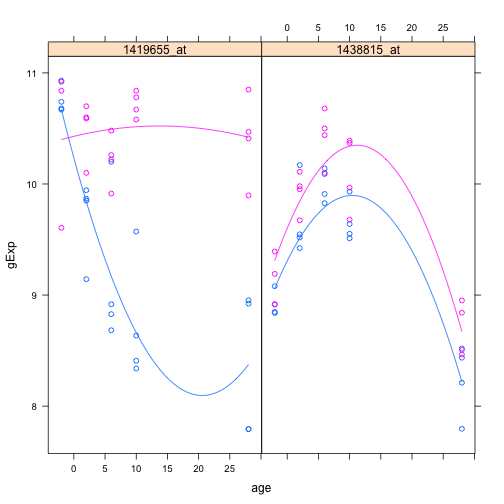

```r
> xyplotQua(gDat)
```

```r
> modelFiteQua(gDat)
```

```
$`1419655_at`

Call:
lm(formula = gExp ~ gType * (age + I(age^2)), data = x)

Coefficients:
        (Intercept)           gTypeNrlKO                  age
           10.23554              0.19321             -0.20791
           I(age^2)       gTypeNrlKO:age  gTypeNrlKO:I(age^2)
            0.00505              0.22152             -0.00555


$`1438815_at`

Call:
lm(formula = gExp ~ gType * (age + I(age^2)), data = x)

Coefficients:
        (Intercept)           gTypeNrlKO                  age
           9.306973             0.294119             0.113183
           I(age^2)       gTypeNrlKO:age  gTypeNrlKO:I(age^2)
          -0.005429             0.020243            -0.000521


attr(,"split_type")
[1] "data.frame"
attr(,"split_labels")
        gene
1 1419655_at
2 1438815_at
```

#### 3. Drop the 4 week data and revisit this dataset with linear and quadratic models.

(a) Prepare a function to drop the 4 week data.

```r
> DropFourWeek <- function(myGenes){
+   Dat <- prepareData(myGenes)
+   Dat <- droplevels(subset(Dat, devStage != "4_weeks"))
+   return(Dat)
+   }
```

(b) Use probes “1419655_at” and “1438815_at” to test if the functions work.

```r
> hDat <- DropFourWeek(c("1419655_at","1438815_at"))
> str(hDat)
```

```
'data.frame':   62 obs. of  7 variables:
 $ sidChar : chr  "Sample_20" "Sample_21" "Sample_22" "Sample_23" ...
 $ sidNum  : num  20 21 22 23 16 17 6 24 25 26 ...
 $ devStage: Factor w/ 4 levels "E16","P2","P6",..: 1 1 1 1 1 1 1 2 2 2 ...
 $ gType   : Factor w/ 2 levels "wt","NrlKO": 1 1 1 1 2 2 2 1 1 1 ...
 $ age     : num  -2 -2 -2 -2 -2 -2 -2 2 2 2 ...
 $ gExp    : num  10.93 10.74 10.67 10.68 9.61 ...
 $ gene    : Factor w/ 2 levels "1419655_at","1438815_at": 1 1 1 1 1 1 1 1 1 1 ...
```

© Fit linear models.

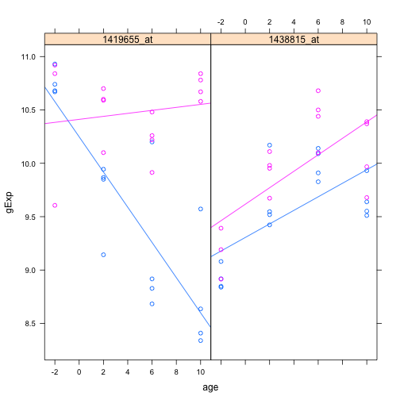

```r
> xyplotLin(hDat)
```

```r
> modelFitLin(hDat)
```

```
$`1419655_at`

Call:
lm(formula = gExp ~ gType * age, data = x)

Coefficients:
   (Intercept)      gTypeNrlKO             age  gTypeNrlKO:age
        10.247           0.164          -0.165           0.179


$`1438815_at`

Call:
lm(formula = gExp ~ gType * age, data = x)

Coefficients:
   (Intercept)      gTypeNrlKO             age  gTypeNrlKO:age
        9.3052          0.3114          0.0635          0.0137


attr(,"split_type")
[1] "data.frame"
attr(,"split_labels")
        gene
1 1419655_at
2 1438815_at
```

(d) Fit quadratic models.

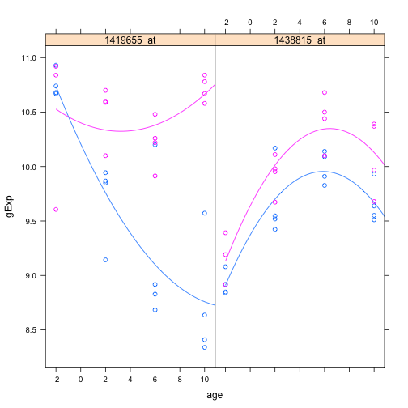

```r
> xyplotQua(hDat)
```

```r
> modelFiteQua(hDat)
```

```
$`1419655_at`

Call:
lm(formula = gExp ~ gType * (age + I(age^2)), data = x)

Coefficients:
        (Intercept)           gTypeNrlKO                  age
           10.20745              0.19424             -0.24430
           I(age^2)       gTypeNrlKO:age  gTypeNrlKO:I(age^2)
            0.00994              0.19628             -0.00252


$`1438815_at`

Call:
lm(formula = gExp ~ gType * (age + I(age^2)), data = x)

Coefficients:
        (Intercept)           gTypeNrlKO                  age
           9.372512             0.267020             0.198075
           I(age^2)       gTypeNrlKO:age  gTypeNrlKO:I(age^2)
          -0.016828             0.022897            -0.000368


attr(,"split_type")
[1] "data.frame"
attr(,"split_labels")
        gene
1 1419655_at
2 1438815_at
```